# The Analytics Edge (Unit 2)

Na Sai

March 22, 2015

# Lectures

## L1. An Introduction to Linear Regression

1.

```r
y <- function(x){
  3*x+2
  }
y(0)
```

```
## [1] 2
```

```r
SSE <- (2-y(0))^2 + (2-y(1))^2 + (8-y(1))^2
SSE
```

```
## [1] 18
```

```r
SST = (2-4)^2 + (2-4)^2 + (8-4)^2
SST
```

```
## [1] 24
```

```r
Rsquare = 1- SSE/SST
Rsquare
```

```
## [1] 0.25
```

4. In R, use the dataset wine.csv to create a linear regression model to predict Price using HarvestRain and WinterRain as independent variables. Using the summary output of this model, answer the following questions:

```r
wine<-read.csv("wine.csv")
str(wine)
```

```
## 'data.frame':    25 obs. of  7 variables:
##  $ Year       : int  1952 1953 1955 1957 1958 1959 1960 1961 1962 1963 ...
##  $ Price      : num  7.5 8.04 7.69 6.98 6.78 ...
##  $ WinterRain : int  600 690 502 420 582 485 763 830 697 608 ...
##  $ AGST       : num  17.1 16.7 17.1 16.1 16.4 ...
##  $ HarvestRain: int  160 80 130 110 187 187 290 38 52 155 ...
##  $ Age        : int  31 30 28 26 25 24 23 22 21 20 ...
##  $ FrancePop  : num  43184 43495 44218 45152 45654 ...
```

```r
model <- lm(Price ~ HarvestRain + WinterRain, data = wine)
summary(model)
```

```
##
## Call:
## lm(formula = Price ~ HarvestRain + WinterRain, data = wine)
##
## Residuals:
##     Min      1Q  Median      3Q     Max
## -1.0933 -0.3222 -0.1012  0.3871  1.1877
##
## Coefficients:
##               Estimate Std. Error t value Pr(>|t|)
## (Intercept)  7.865e+00  6.616e-01  11.888 4.76e-11 ***
## HarvestRain -4.971e-03  1.601e-03  -3.105  0.00516 **
## WinterRain  -9.848e-05  9.007e-04  -0.109  0.91392
## ---
## Signif. codes:  0 '***' 0.001 '**' 0.01 '*' 0.05 '.' 0.1 ' ' 1
##
## Residual standard error: 0.5611 on 22 degrees of freedom
## Multiple R-squared:  0.3177, Adjusted R-squared:  0.2557
## F-statistic: 5.122 on 2 and 22 DF,  p-value: 0.01492
```

```r
#what is the correlation between HarvestRain and WinterRain?
cor(wine$HarvestRain,wine$WinterRain)
```

```
## [1] -0.2754409
```

## L2. Moneyball:The power of Sports Analytics

### Quick question

```r
#If a baseball team scores 713 runs and allows 614 runs, how many games do we expect the team to win?
baseball <- read.csv("baseball.csv")
moneyball <- subset(baseball,Year < 2002)
```

# Assignment 2

## 1. Climate Change

There have been many studies documenting that the average global temperature has been increasing over the last century. The consequences of a continued rise in global temperature will be dire. Rising sea levels and an increased frequency of extreme weather events will affect billions of people.

In this problem, we will attempt to study the relationship between average global temperature and several other factors.

The file climate_change.csv contains climate data from May 1983 to December 2008.

```r
climate<-read.csv("climate_change.csv")
str(climate)
```

```
## 'data.frame':    308 obs. of  11 variables:
##  $ Year    : int  1983 1983 1983 1983 1983 1983 1983 1983 1984 1984 ...
##  $ Month   : int  5 6 7 8 9 10 11 12 1 2 ...
##  $ MEI     : num  2.556 2.167 1.741 1.13 0.428 ...
##  $ CO2     : num  346 346 344 342 340 ...
##  $ CH4     : num  1639 1634 1633 1631 1648 ...
##  $ N2O     : num  304 304 304 304 304 ...
##  $ CFC.11  : num  191 192 193 194 194 ...
##  $ CFC.12  : num  350 352 354 356 357 ...
##  $ TSI     : num  1366 1366 1366 1366 1366 ...
##  $ Aerosols: num  0.0863 0.0794 0.0731 0.0673 0.0619 0.0569 0.0524 0.0486 0.0451 0.0416 ...
##  $ Temp    : num  0.109 0.118 0.137 0.176 0.149 0.093 0.232 0.078 0.089 0.013 ...
```

```r
### Problem 1.1 - Creating Our First Model
climateTrain <- subset(climate, Year<=2006)
model<- lm(Temp ~ MEI + CO2 + CH4 + N2O + CFC.11 + CFC.12 + TSI + Aerosols, data=climateTrain)
summary(model)
```

```
##
## Call:
## lm(formula = Temp ~ MEI + CO2 + CH4 + N2O + CFC.11 + CFC.12 +
##     TSI + Aerosols, data = climateTrain)
##
## Residuals:
##      Min       1Q   Median       3Q      Max
## -0.25888 -0.05913 -0.00082  0.05649  0.32433
##
## Coefficients:
##               Estimate Std. Error t value Pr(>|t|)
## (Intercept) -1.246e+02  1.989e+01  -6.265 1.43e-09 ***
## MEI          6.421e-02  6.470e-03   9.923  < 2e-16 ***
## CO2          6.457e-03  2.285e-03   2.826  0.00505 **
## CH4          1.240e-04  5.158e-04   0.240  0.81015
## N2O         -1.653e-02  8.565e-03  -1.930  0.05467 .
## CFC.11      -6.631e-03  1.626e-03  -4.078 5.96e-05 ***
## CFC.12       3.808e-03  1.014e-03   3.757  0.00021 ***
## TSI          9.314e-02  1.475e-02   6.313 1.10e-09 ***
## Aerosols    -1.538e+00  2.133e-01  -7.210 5.41e-12 ***
## ---
## Signif. codes:  0 '***' 0.001 '**' 0.01 '*' 0.05 '.' 0.1 ' ' 1
##
## Residual standard error: 0.09171 on 275 degrees of freedom
## Multiple R-squared:  0.7509, Adjusted R-squared:  0.7436
## F-statistic: 103.6 on 8 and 275 DF,  p-value: < 2.2e-16
```

```r
# Problem 2.2 - Understanding the Model
cor(climateTrain)
```

```
##                 Year         Month           MEI         CO2         CH4
## Year      1.00000000 -0.0279419602 -0.0369876842  0.98274939  0.91565945
## Month    -0.02794196  1.0000000000  0.0008846905 -0.10673246  0.01856866
## MEI      -0.03698768  0.0008846905  1.0000000000 -0.04114717 -0.03341930
## CO2       0.98274939 -0.1067324607 -0.0411471651  1.00000000  0.87727963
## CH4       0.91565945  0.0185686624 -0.0334193014  0.87727963  1.00000000
## N2O       0.99384523  0.0136315303 -0.0508197755  0.97671982  0.89983864
## CFC.11    0.56910643 -0.0131112236  0.0690004387  0.51405975  0.77990402
## CFC.12    0.89701166  0.0006751102  0.0082855443  0.85268963  0.96361625
## TSI       0.17030201 -0.0346061935 -0.1544919227  0.17742893  0.24552844
## Aerosols -0.34524670  0.0148895406  0.3402377871 -0.35615480 -0.26780919
## Temp      0.78679714 -0.0998567411  0.1724707512  0.78852921  0.70325502
##                  N2O      CFC.11        CFC.12         TSI    Aerosols
## Year      0.99384523  0.56910643  0.8970116635  0.17030201 -0.34524670
## Month     0.01363153 -0.01311122  0.0006751102 -0.03460619  0.01488954
## MEI      -0.05081978  0.06900044  0.0082855443 -0.15449192  0.34023779
## CO2       0.97671982  0.51405975  0.8526896272  0.17742893 -0.35615480
## CH4       0.89983864  0.77990402  0.9636162478  0.24552844 -0.26780919
## N2O       1.00000000  0.52247732  0.8679307757  0.19975668 -0.33705457
## CFC.11    0.52247732  1.00000000  0.8689851828  0.27204596 -0.04392120
## CFC.12    0.86793078  0.86898518  1.0000000000  0.25530281 -0.22513124
## TSI       0.19975668  0.27204596  0.2553028138  1.00000000  0.05211651
## Aerosols -0.33705457 -0.04392120 -0.2251312440  0.05211651  1.00000000
## Temp      0.77863893  0.40771029  0.6875575483  0.24338269 -0.38491375
##                 Temp
## Year      0.78679714
## Month    -0.09985674
## MEI       0.17247075
## CO2       0.78852921
## CH4       0.70325502
## N2O       0.77863893
## CFC.11    0.40771029
## CFC.12    0.68755755
## TSI       0.24338269
## Aerosols -0.38491375
## Temp      1.00000000
```

```r
modelReduc<-lm(Temp ~ MEI + N2O + TSI + Aerosols, data=climateTrain)
summary(modelReduc)
```

```
##
## Call:
## lm(formula = Temp ~ MEI + N2O + TSI + Aerosols, data = climateTrain)
##
## Residuals:
##      Min       1Q   Median       3Q      Max
## -0.27916 -0.05975 -0.00595  0.05672  0.34195
##
## Coefficients:
##               Estimate Std. Error t value Pr(>|t|)
## (Intercept) -1.162e+02  2.022e+01  -5.747 2.37e-08 ***
## MEI          6.419e-02  6.652e-03   9.649  < 2e-16 ***
## N2O          2.532e-02  1.311e-03  19.307  < 2e-16 ***
## TSI          7.949e-02  1.487e-02   5.344 1.89e-07 ***
## Aerosols    -1.702e+00  2.180e-01  -7.806 1.19e-13 ***
## ---
## Signif. codes:  0 '***' 0.001 '**' 0.01 '*' 0.05 '.' 0.1 ' ' 1
##
## Residual standard error: 0.09547 on 279 degrees of freedom
## Multiple R-squared:  0.7261, Adjusted R-squared:  0.7222
## F-statistic: 184.9 on 4 and 279 DF,  p-value: < 2.2e-16
```

```r
#Problem 4 - Automatically Building the Model
modelSim<-step(model)
```

```
## Start:  AIC=-1348.16
## Temp ~ MEI + CO2 + CH4 + N2O + CFC.11 + CFC.12 + TSI + Aerosols
##
##            Df Sum of Sq    RSS     AIC
## - CH4       1   0.00049 2.3135 -1350.1
## <none>                  2.3130 -1348.2
## - N2O       1   0.03132 2.3443 -1346.3
## - CO2       1   0.06719 2.3802 -1342.0
## - CFC.12    1   0.11874 2.4318 -1335.9
## - CFC.11    1   0.13986 2.4529 -1333.5
## - TSI       1   0.33516 2.6482 -1311.7
## - Aerosols  1   0.43727 2.7503 -1301.0
## - MEI       1   0.82823 3.1412 -1263.2
##
## Step:  AIC=-1350.1
## Temp ~ MEI + CO2 + N2O + CFC.11 + CFC.12 + TSI + Aerosols
##
##            Df Sum of Sq    RSS     AIC
## <none>                  2.3135 -1350.1
## - N2O       1   0.03133 2.3448 -1348.3
## - CO2       1   0.06672 2.3802 -1344.0
## - CFC.12    1   0.13023 2.4437 -1336.5
## - CFC.11    1   0.13938 2.4529 -1335.5
## - TSI       1   0.33500 2.6485 -1313.7
## - Aerosols  1   0.43987 2.7534 -1302.7
## - MEI       1   0.83118 3.1447 -1264.9
```

```r
summary(modelSim)
```

```
##
## Call:
## lm(formula = Temp ~ MEI + CO2 + N2O + CFC.11 + CFC.12 + TSI +
##     Aerosols, data = climateTrain)
##
## Residuals:
##      Min       1Q   Median       3Q      Max
## -0.25770 -0.05994 -0.00104  0.05588  0.32203
##
## Coefficients:
##               Estimate Std. Error t value Pr(>|t|)
## (Intercept) -1.245e+02  1.985e+01  -6.273 1.37e-09 ***
## MEI          6.407e-02  6.434e-03   9.958  < 2e-16 ***
## CO2          6.402e-03  2.269e-03   2.821 0.005129 **
## N2O         -1.602e-02  8.287e-03  -1.933 0.054234 .
## CFC.11      -6.609e-03  1.621e-03  -4.078 5.95e-05 ***
## CFC.12       3.868e-03  9.812e-04   3.942 0.000103 ***
## TSI          9.312e-02  1.473e-02   6.322 1.04e-09 ***
## Aerosols    -1.540e+00  2.126e-01  -7.244 4.36e-12 ***
## ---
## Signif. codes:  0 '***' 0.001 '**' 0.01 '*' 0.05 '.' 0.1 ' ' 1
##
## Residual standard error: 0.09155 on 276 degrees of freedom
## Multiple R-squared:  0.7508, Adjusted R-squared:  0.7445
## F-statistic: 118.8 on 7 and 276 DF,  p-value: < 2.2e-16
```

```r
# Problem 5 - Testing on Unseen Data
climateTest <- subset(climate, Year>2006)
predTemp <- predict(modelSim, newdata=climateTest)
predTemp
```

```
##       285       286       287       288       289       290       291
## 0.4677808 0.4435404 0.4265541 0.4299162 0.4455113 0.4151422 0.4097367
##       292       293       294       295       296       297       298
## 0.3839390 0.3255595 0.3274147 0.3231401 0.3316704 0.3522134 0.3313129
##       299       300       301       302       303       304       305
## 0.3142112 0.3703410 0.4162213 0.4391458 0.4237965 0.3913679 0.3587615
##       306       307       308
## 0.3451991 0.3607087 0.3638076
```

```r
SSE <- sum((climateTest$Temp - predTemp)^2)
SST <- sum((climateTest$Temp -mean(climateTrain$Temp))^2)
1-SSE/SST
```

```
## [1] 0.6286051
```

## 2. Reading Test Scores

The Programme for International Student Assessment (PISA) is a test given every three years to 15-year-old students from around the world to evaluate their performance in mathematics, reading, and science. This test provides a quantitative way to compare the performance of students from different parts of the world. In this homework assignment, we will predict the reading scores of students from the United States of America on the 2009 PISA exam.

The datasets pisa2009train.csv and pisa2009test.csv contain information about the demographics and schools for American students taking the exam, derived from 2009 PISA Public-Use Data Files distributed by the United States National Center for Education Statistics (NCES). While the datasets are not supposed to contain identifying information about students taking the test, by using the data you are bound by the NCES data use agreement, which prohibits any attempt to determine the identity of any student in the datasets.

```r
pisaTrain<-read.csv("pisa2009train.csv")
pisaTest<-read.csv("pisa2009test.csv")
dim(pisaTrain)
```

```
## [1] 3663   24
```

```r
dim(pisaTest)
```

```
## [1] 1570   24
```

```r
# Problem 1.2 - Summarizing the DataSet
tapply(pisaTrain$readingScore,pisaTrain$male,mean)
```

```
##        0        1
## 512.9406 483.5325
```

```r
#Problem 1.3 - Locating missing values
summary(pisaTrain)
```

```
##      grade            male                      raceeth
##  Min.   : 8.00   Min.   :0.0000   White             :2015
##  1st Qu.:10.00   1st Qu.:0.0000   Hispanic          : 834
##  Median :10.00   Median :1.0000   Black             : 444
##  Mean   :10.09   Mean   :0.5111   Asian             : 143
##  3rd Qu.:10.00   3rd Qu.:1.0000   More than one race: 124
##  Max.   :12.00   Max.   :1.0000   (Other)           :  68
##                                   NA's              :  35
##    preschool      expectBachelors     motherHS    motherBachelors
##  Min.   :0.0000   Min.   :0.0000   Min.   :0.00   Min.   :0.0000
##  1st Qu.:0.0000   1st Qu.:1.0000   1st Qu.:1.00   1st Qu.:0.0000
##  Median :1.0000   Median :1.0000   Median :1.00   Median :0.0000
##  Mean   :0.7228   Mean   :0.7859   Mean   :0.88   Mean   :0.3481
##  3rd Qu.:1.0000   3rd Qu.:1.0000   3rd Qu.:1.00   3rd Qu.:1.0000
##  Max.   :1.0000   Max.   :1.0000   Max.   :1.00   Max.   :1.0000
##  NA's   :56       NA's   :62       NA's   :97     NA's   :397
##    motherWork        fatherHS      fatherBachelors    fatherWork
##  Min.   :0.0000   Min.   :0.0000   Min.   :0.0000   Min.   :0.0000
##  1st Qu.:0.0000   1st Qu.:1.0000   1st Qu.:0.0000   1st Qu.:1.0000
##  Median :1.0000   Median :1.0000   Median :0.0000   Median :1.0000
##  Mean   :0.7345   Mean   :0.8593   Mean   :0.3319   Mean   :0.8531
##  3rd Qu.:1.0000   3rd Qu.:1.0000   3rd Qu.:1.0000   3rd Qu.:1.0000
##  Max.   :1.0000   Max.   :1.0000   Max.   :1.0000   Max.   :1.0000
##  NA's   :93       NA's   :245      NA's   :569      NA's   :233
##    selfBornUS      motherBornUS     fatherBornUS    englishAtHome
##  Min.   :0.0000   Min.   :0.0000   Min.   :0.0000   Min.   :0.0000
##  1st Qu.:1.0000   1st Qu.:1.0000   1st Qu.:1.0000   1st Qu.:1.0000
##  Median :1.0000   Median :1.0000   Median :1.0000   Median :1.0000
##  Mean   :0.9313   Mean   :0.7725   Mean   :0.7668   Mean   :0.8717
##  3rd Qu.:1.0000   3rd Qu.:1.0000   3rd Qu.:1.0000   3rd Qu.:1.0000
##  Max.   :1.0000   Max.   :1.0000   Max.   :1.0000   Max.   :1.0000
##  NA's   :69       NA's   :71       NA's   :113      NA's   :71
##  computerForSchoolwork read30MinsADay   minutesPerWeekEnglish
##  Min.   :0.0000        Min.   :0.0000   Min.   :   0.0
##  1st Qu.:1.0000        1st Qu.:0.0000   1st Qu.: 225.0
##  Median :1.0000        Median :0.0000   Median : 250.0
##  Mean   :0.8994        Mean   :0.2899   Mean   : 266.2
##  3rd Qu.:1.0000        3rd Qu.:1.0000   3rd Qu.: 300.0
##  Max.   :1.0000        Max.   :1.0000   Max.   :2400.0
##  NA's   :65            NA's   :34       NA's   :186
##  studentsInEnglish schoolHasLibrary  publicSchool        urban
##  Min.   : 1.0      Min.   :0.0000   Min.   :0.0000   Min.   :0.0000
##  1st Qu.:20.0      1st Qu.:1.0000   1st Qu.:1.0000   1st Qu.:0.0000
##  Median :25.0      Median :1.0000   Median :1.0000   Median :0.0000
##  Mean   :24.5      Mean   :0.9676   Mean   :0.9339   Mean   :0.3849
##  3rd Qu.:30.0      3rd Qu.:1.0000   3rd Qu.:1.0000   3rd Qu.:1.0000
##  Max.   :75.0      Max.   :1.0000   Max.   :1.0000   Max.   :1.0000
##  NA's   :249       NA's   :143
##    schoolSize    readingScore
##  Min.   : 100   Min.   :168.6
##  1st Qu.: 712   1st Qu.:431.7
##  Median :1212   Median :499.7
##  Mean   :1369   Mean   :497.9
##  3rd Qu.:1900   3rd Qu.:566.2
##  Max.   :6694   Max.   :746.0
##  NA's   :162
```

```r
#Problem 1.4 - Removing missing values
pisaTrain = na.omit(pisaTrain)
pisaTest = na.omit(pisaTest)
dim(pisaTrain)
```

```
## [1] 2414   24
```

```r
dim(pisaTest)
```

```
## [1] 990  24
```

### Problem 2.2 - Unordered factors in regression models

```r
pisaTrain$raceth = relevel(pisaTrain$raceeth,"White")
pisaTest$raceth = relevel(pisaTest$raceeth,"White")
lmScore <- lm(readingScore ~ ., data = pisaTrain)
summary(lmScore)
```

```
##
## Call:
## lm(formula = readingScore ~ ., data = pisaTrain)
##
## Residuals:
##     Min      1Q  Median      3Q     Max
## -247.44  -48.86    1.86   49.77  217.18
##
## Coefficients: (6 not defined because of singularities)
##                                                 Estimate Std. Error
## (Intercept)                                    76.489006  37.302678
## grade                                          29.542707   2.937399
## male                                          -14.521653   3.155926
## raceethAsian                                   63.167002  18.972648
## raceethBlack                                    0.264980  17.369507
## raceethHispanic                                28.301842  17.258860
## raceethMore than one race                      50.354805  18.570123
## raceethNative Hawaiian/Other Pacific Islander  62.175726  23.782766
## raceethWhite                                   67.277327  16.786935
## preschool                                      -4.463670   3.486055
## expectBachelors                                55.267080   4.293893
## motherHS                                        6.058774   6.091423
## motherBachelors                                12.638068   3.861457
## motherWork                                     -2.809101   3.521827
## fatherHS                                        4.018214   5.579269
## fatherBachelors                                16.929755   3.995253
## fatherWork                                      5.842798   4.395978
## selfBornUS                                     -3.806278   7.323718
## motherBornUS                                   -8.798153   6.587621
## fatherBornUS                                    4.306994   6.263875
## englishAtHome                                   8.035685   6.859492
## computerForSchoolwork                          22.500232   5.702562
## read30MinsADay                                 34.871924   3.408447
## minutesPerWeekEnglish                           0.012788   0.010712
## studentsInEnglish                              -0.286631   0.227819
## schoolHasLibrary                               12.215085   9.264884
## publicSchool                                  -16.857475   6.725614
## urban                                          -0.110132   3.962724
## schoolSize                                      0.006540   0.002197
## racethAmerican Indian/Alaska Native                   NA         NA
```

[output cut: 32 more lines]

```
## publicSchool                                   -2.506 0.012261 *
## urban                                          -0.028 0.977830
## schoolSize                                      2.977 0.002942 **
## racethAmerican Indian/Alaska Native                NA       NA
## racethAsian                                        NA       NA
## racethBlack                                        NA       NA
## racethHispanic                                     NA       NA
## racethMore than one race                           NA       NA
## racethNative Hawaiian/Other Pacific Islander       NA       NA
## ---
## Signif. codes:  0 '***' 0.001 '**' 0.01 '*' 0.05 '.' 0.1 ' ' 1
##
## Residual standard error: 73.81 on 2385 degrees of freedom
## Multiple R-squared:  0.3251, Adjusted R-squared:  0.3172
## F-statistic: 41.04 on 28 and 2385 DF,  p-value: < 2.2e-16
```

```r
RMSE <- sqrt(sum(residuals(lmScore)^2)/dim(pisaTrain)[1])
RMSE
```

```
## [1] 73.36555
```

### Problem 3.3 - Comparing predictions for similar students

Consider two students A and B. They have all variable values the same, except that student A is in grade 11 and student B is in grade 9. What is the predicted reading score of student A minus the predicted reading score of student B?

```r
coef(lmScore)[2]*(11-9)
```

```
##    grade
## 59.08541
```

### Problem 4.1 - Predicting on unseen data

```r
predScore <- predict(lmScore,newdata = pisaTest)
summary(predScore)
```

```
##    Min. 1st Qu.  Median    Mean 3rd Qu.    Max.
##   353.2   482.0   524.0   516.7   555.7   637.7
```

```r
summary(predScore)[6] - summary(predScore)[1]
```

```
##  Max.
## 284.5
```

```r
#What is the sum of squared errors (SSE) of lmScore on the testing set?
SSE = sum((predScore - pisaTest$readingScore)^2)
SSE
```

```
## [1] 5762082
```

```r
#What is the root-mean squared error (RMSE) of lmScore on the testing set?
RMSE = sqrt(SSE/dim(pisaTest)[1])
RMSE
```

```
## [1] 76.29079
```

```r
#What is the predicted test score used in the baseline model?
mean(pisaTrain$readingScore)
```

```
## [1] 517.9629
```

```r
#What is the sum of squared errors of the baseline model on the testing set?
SST = sum((pisaTest$readingScore - mean(pisaTrain$readingScore))^2)
SST
```

```
## [1] 7802354
```

```r
#What is the test-set R-squared value of lmScore?
1 - SSE/SST
```

```
## [1] 0.2614944
```

## 3. Detecting Flu Epidemics via Search Engine Query Data

The U.S. Centers for Disease Control and Prevention (CDC) and the European Influenza Surveillance Scheme (EISS) detect influenza activity through virologic and clinical data, including Influenza-like Illness (ILI) physician visits. Reporting national and regional data, however, are published with a 1-2 week lag.

The Google Flu Trends project was initiated to see if faster reporting can be made possible by considering flu-related online search queries – data that is available almost immediately.

```r
#Looking at the time period 2004-2011, which week corresponds to the highest percentage of ILI-related physician visits?
fluTrain <- read.csv("FluTrain.csv")
str(fluTrain)
```

```
## 'data.frame':    417 obs. of  3 variables:
##  $ Week   : Factor w/ 417 levels "2004-01-04 - 2004-01-10",..: 1 2 3 4 5 6 7 8 9 10 ...
##  $ ILI    : num  2.42 1.81 1.71 1.54 1.44 ...
##  $ Queries: num  0.238 0.22 0.226 0.238 0.224 ...
```

```r
which.max(fluTrain$ILI)
```

```
## [1] 303
```

```r
fluTrain$Week[303]
```

```
## [1] 2009-10-18 - 2009-10-24
## 417 Levels: 2004-01-04 - 2004-01-10 ... 2011-12-25 - 2011-12-31
```

```r
which.max(fluTrain$Queries)
```

```
## [1] 303
```

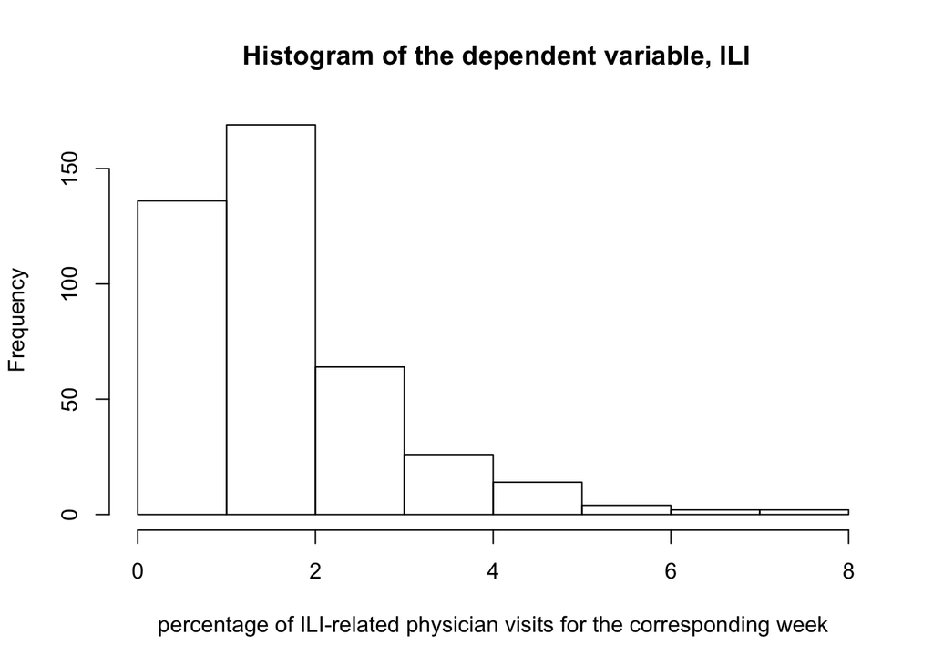

```r
hist(fluTrain$ILI,xlab = "percentage of ILI-related physician visits for the corresponding week",main=" Histogram of the dependent variable, ILI")
```

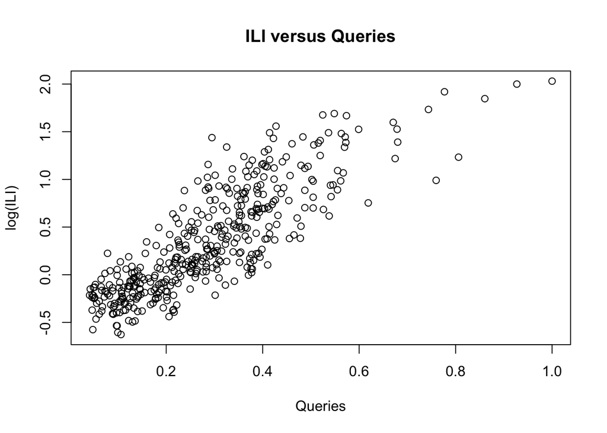

```r
plot(fluTrain$Queries, log(fluTrain$ILI),main="ILI versus Queries",ylab="log(ILI)",xlab="Queries")
```

### Problem 2.1 - Linear Regression Model

```r
FluTrend1 <- lm(log(ILI)~Queries,data = fluTrain)
summary(FluTrend1)
```

```
##
## Call:
## lm(formula = log(ILI) ~ Queries, data = fluTrain)
##
## Residuals:
##      Min       1Q   Median       3Q      Max
## -0.76003 -0.19696 -0.01657  0.18685  1.06450
##
## Coefficients:
##             Estimate Std. Error t value Pr(>|t|)
## (Intercept) -0.49934    0.03041  -16.42   <2e-16 ***
## Queries      2.96129    0.09312   31.80   <2e-16 ***
## ---
## Signif. codes:  0 '***' 0.001 '**' 0.01 '*' 0.05 '.' 0.1 ' ' 1
##
## Residual standard error: 0.2995 on 415 degrees of freedom
## Multiple R-squared:  0.709,  Adjusted R-squared:  0.7083
## F-statistic:  1011 on 1 and 415 DF,  p-value: < 2.2e-16
```

```r
cor(log(fluTrain$ILI),fluTrain$Queries)
```

```
## [1] 0.8420333
```

```r
#cor^2 = R-squared
```

### Problem 3.1 - Performance on the Test Set

```r
fluTest<-read.csv("FluTest.csv")
PredTest1 <- exp(predict(FluTrend1,newdata = fluTest))
#What is our estimate for the percentage of ILI-related physician visits for the week of March 11, 2012?
PredTest1[which(fluTest$Week=='2012-03-11 - 2012-03-17')]
```

```
##       11
## 2.187378
```

```r
#What is the relative error betweeen the estimate (our prediction) and the observed value for the week of March 11, 2012?
week<-which(fluTest$Week=='2012-03-11 - 2012-03-17')
(fluTest$ILI[week] - PredTest1[week])/fluTest$ILI[week]
```

```
##         11
## 0.04623827
```

```r
#What is the Root Mean Square Error (RMSE) between our estimates and the actual observations for the percentage of ILI-related physician visits, on the test set?
RMSE = sqrt(sum((PredTest1 - fluTest$ILI)^2)/dim(fluTest)[1])
RMSE
```

```
## [1] 0.7490645
```

### Problem 4.1 - Training a Time Series Model

The observations in this dataset are consecutive weekly measurements of the dependent and independent variables. This sort of dataset is called a “time series.” Often, statistical models can be improved by predicting the current value of the dependent variable using the value of the dependent variable from earlier weeks. In our models, this means we will predict the ILI variable in the current week using values of the ILI variable from previous weeks.To do so, we will use the “zoo” package, which provides a number of helpful methods for time series models.

```r
#install.packages("zoo")
library(zoo)
ILILag2 <- lag(zoo(fluTrain$ILI), -2, na.pad = TRUE)
fluTrain$ILILag2 <- coredata(ILILag2)
#How many values are missing in the new ILILag2 variable?
table(is.na(fluTrain$ILILag2))
```

```
##
## FALSE  TRUE
##   415     2
```

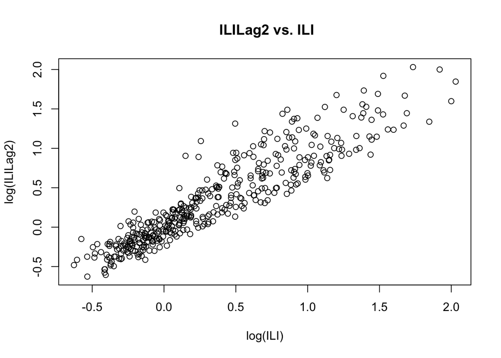

```r
plot(log(fluTrain$ILILag2),log(fluTrain$ILI),main= ' ILILag2 vs. ILI',xlab = 'log(ILI)',ylab = 'log(ILILag2)')
```

```r
#Train a linear regression model on the FluTrain dataset to predict the log of the ILI variable using the Queries variable as well as the log of the ILILag2 variable.
FluTrend2 <- lm(log(ILI)~Queries + log(ILILag2), data = fluTrain)
summary(FluTrend2)
```

```
##
## Call:
## lm(formula = log(ILI) ~ Queries + log(ILILag2), data = fluTrain)
##
## Residuals:
##      Min       1Q   Median       3Q      Max
## -0.52209 -0.11082 -0.01819  0.08143  0.76785
##
## Coefficients:
##              Estimate Std. Error t value Pr(>|t|)
## (Intercept)  -0.24064    0.01953  -12.32   <2e-16 ***
## Queries       1.25578    0.07910   15.88   <2e-16 ***
## log(ILILag2)  0.65569    0.02251   29.14   <2e-16 ***
## ---
## Signif. codes:  0 '***' 0.001 '**' 0.01 '*' 0.05 '.' 0.1 ' ' 1
##
## Residual standard error: 0.1703 on 412 degrees of freedom
##   (2 observations deleted due to missingness)
## Multiple R-squared:  0.9063, Adjusted R-squared:  0.9059
## F-statistic:  1993 on 2 and 412 DF,  p-value: < 2.2e-16
```

### Problem 5.1 - Evaluating the Time Series Model in the Test Set

```r
ILILag2<-lag(zoo(fluTest$ILI), -2, na.pad = TRUE)
fluTest$ILILag2 <- coredata(ILILag2)
table(is.na(fluTest$ILILag2))
```

```
##
## FALSE  TRUE
##    50     2
```

```r
#In this problem, the training and testing sets are split sequentially -- the training set contains all observations from 2004-2011 and the testing set contains all observations from 2012.
#Fill in the missing values for ILILag2 in FluTest.
fluTest$ILILag2[1] = fluTrain$ILI[dim(fluTrain)[1]-1]
fluTest$ILILag2[2] = fluTrain$ILI[dim(fluTrain)[1]]
#Obtain test set predictions of the ILI variable from the FluTrend2 model
PredTest2 <- exp(predict(FluTrend2,newdata = fluTest))
RMSE <- sqrt(sum((PredTest2 - fluTest$ILI)^2)/dim(fluTest)[1])
RMSE
```

```
## [1] 0.2942029
```